# Parallelisation Experiment

2023-07-20

## 1. Block Range

The experiment was conducted for the block range from 5,000,000 to 6,000,000. The parallelisation experiment was performed with following configuration: **Geth VM and Geth MPT**.

## 2. Degree of Parallelisation

We have 999,380 blocks of which 791,399 are parallelisable. 20.81% of blocks are strictly sequential (not parallelisable) blocks. The maximal achievable parallelism in a block is 4.017. The geometric mean of the speedup is 1.277.

The distribution of the speedup is shown below:

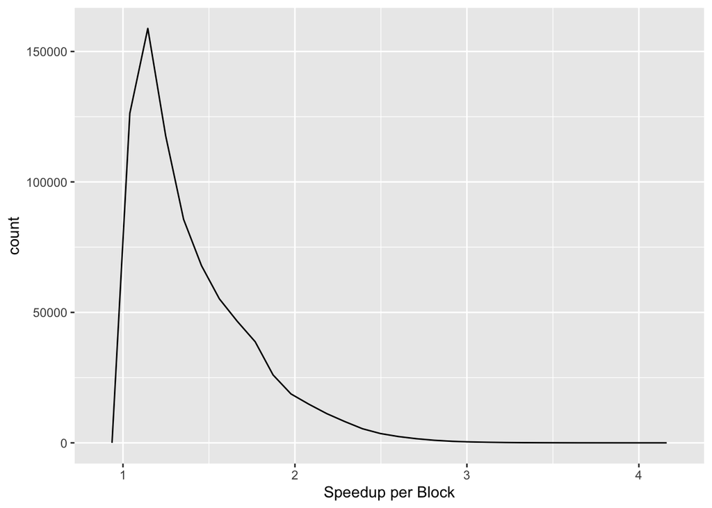

## 3. Number of Transactions per Block

We have on average 4.7767726 transactions per block. The smallest number of transactions per block is 1 and the largest number is 148. The distribution of number of transactions per block is shown below:

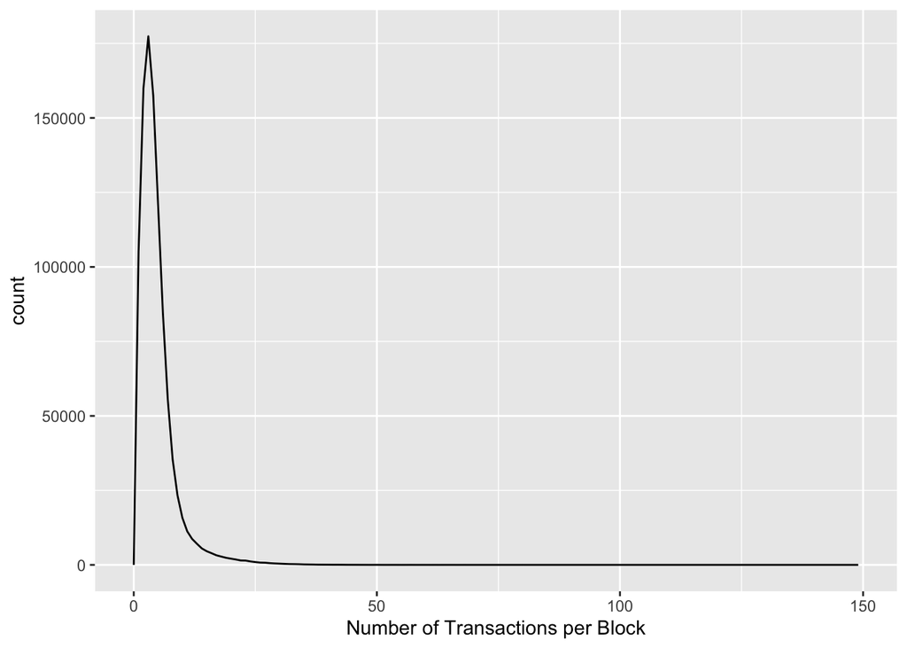

## 4. Processor Utilisation / Efficiency

The lower bound of the processor utilisation is 55.4% on average and with a maximum of 26 processors (upper bound).

## 5. Sequential Block Runtime

The average block execution time is 1.0850675 milliseconds with a minimum of 0.006883 milliseconds and a maximum of 1020.290605 milliseconds. The distribution of the block execution time in nanoseconds is shown below:

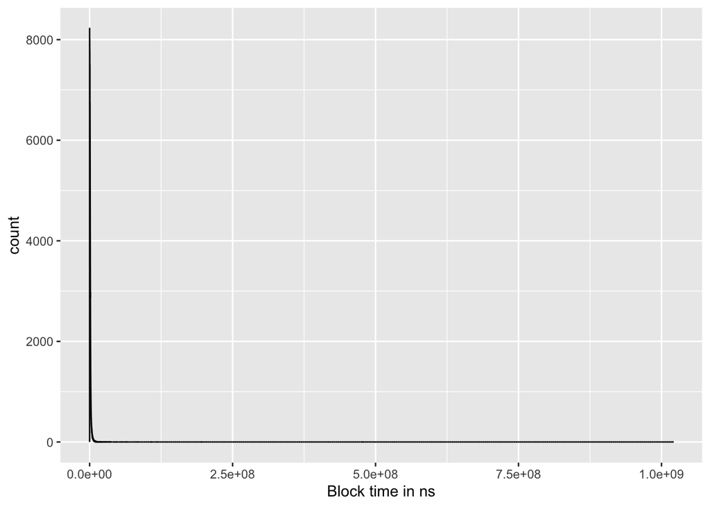

The smoothened trend line for block time in nanoseconds is shown below:

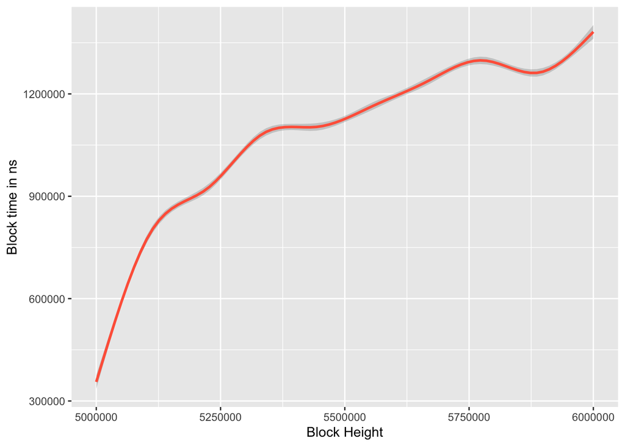

## 6. Commit Time

The average commit time is 0.0618742 milliseconds with a minimum of 0.001272 milliseconds and a maximum of 1019.625819 milliseconds. The distribution of the commit time in nanoseconds is shown below:

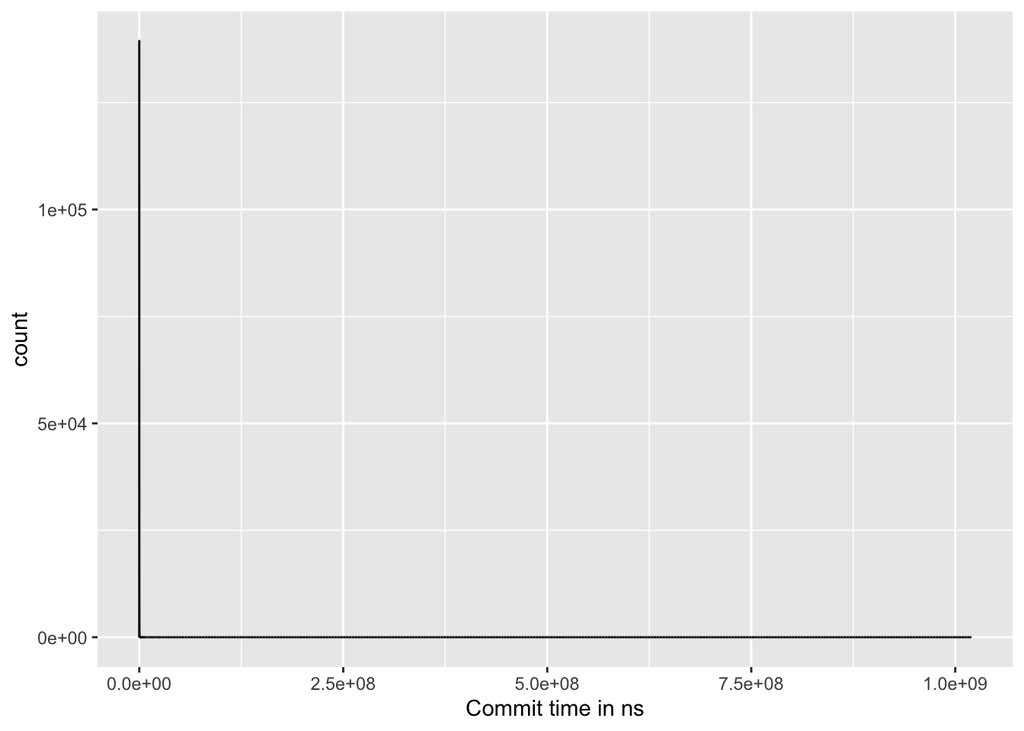

The smoothened trend line of the commit time in nanoseconds is shown below:

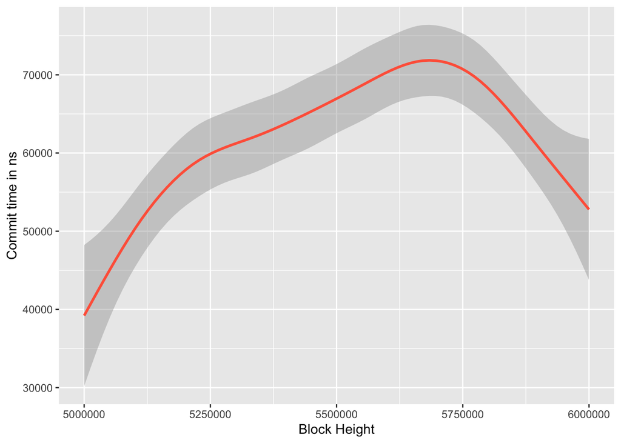